# Assignment 1

Balaji Padmanathan - 22202290

2022-10-14

# Task 1: Manipulation

### Question 1

Loading the “EurostatCrime2019.csv” dataset which contains offences (values per hundred thousand inhabitants) by offence category in 41 European Countries in 2019. After loading, using head() to check if the data is loaded correctly.

```r
Euro_Crime_2019 <- read.csv(file.choose())

head(Euro_Crime_2019)
```

```
##                        X Intentional.homicide Attempted.intentional.homicide
## 1                Albania                 2.03                           3.25
## 2                Austria                 0.84                           1.93
## 3                Belgium                 1.27                           8.87
## 4 Bosnia and Herzegovina                   NA                             NA
## 5               Bulgaria                 1.14                           0.54
## 6                Croatia                 0.81                           2.40
##   Assault Kidnapping Sexual.violence  Rape Sexual.assault Robbery Burglary
## 1    5.52       0.14            5.38  2.69           2.69    3.42       NA
## 2   43.29       0.07           50.90 18.92          26.64   29.67   613.22
## 3  556.36         NA           77.45 33.33          44.12  140.14   565.92
## 4      NA         NA              NA    NA             NA      NA       NA
## 5   39.54       1.03            8.64  1.87             NA   16.90    79.81
## 6   18.06       0.02           21.05 11.58           8.61   20.56   265.73
##   Burglary.of.private.residential.premises   Theft
```

[output cut: 20 more lines]

Reading the first column of the dataset as rownames and displaying it.

```r
rownames(Euro_Crime_2019) <- Euro_Crime_2019[, 1]
Euro_Crime_2019[, 1] <- NULL
row.names(Euro_Crime_2019)
```

```
##  [1] "Albania"
##  [2] "Austria"
##  [3] "Belgium"
##  [4] "Bosnia and Herzegovina"
##  [5] "Bulgaria"
##  [6] "Croatia"
##  [7] "Cyprus"
##  [8] "Czechia"
##  [9] "Denmark"
## [10] "England and Wales"
## [11] "Estonia"
## [12] "Finland"
## [13] "France"
## [14] "Germany (until 1990 former territory of the FRG)"
## [15] "Greece"
```

[output cut: 26 more lines]

### Question 2

Displaying the size and the structure of the dataset.

```r
nrow(Euro_Crime_2019)
```

```
## [1] 41
```

```r
ncol(Euro_Crime_2019)
```

```
## [1] 13
```

```r
dim(Euro_Crime_2019)
```

```
## [1] 41 13
```

```r
str(Euro_Crime_2019)
```

```
## 'data.frame':    41 obs. of  13 variables:
##  $ Intentional.homicide                                  : num  2.03 0.84 1.27 NA 1.14 0.81 1.48 0.76 0.91 NA ...
##  $ Attempted.intentional.homicide                        : num  3.25 1.93 8.87 NA 0.54 2.4 1.71 0.58 2.57 NA ...
##  $ Assault                                               : num  5.52 43.29 556.36 NA 39.54 ...
##  $ Kidnapping                                            : num  0.14 0.07 NA NA 1.03 0.02 0.91 0.11 NA NA ...
##  $ Sexual.violence                                       : num  5.38 50.9 77.45 NA 8.64 ...
##  $ Rape                                                  : num  2.69 18.92 33.33 NA 1.87 ...
##  $ Sexual.assault                                        : num  2.69 26.64 44.12 NA NA ...
##  $ Robbery                                               : num  3.42 29.67 140.14 NA 16.9 ...
##  $ Burglary                                              : num  NA 613.2 565.9 NA 79.8 ...
##  $ Burglary.of.private.residential.premises              : num  40.4 99.3 410.1 NA NA ...
##  $ Theft                                                 : num  169 1303 1952 NA 474 ...
##  $ Theft.of.a.motorized.land.vehicle                     : num  11.1 44.2 109.8 NA 18.9 ...
##  $ Unlawful.acts.involving.controlled.drugs.or.precursors: num  70.3 494.1 547.7 NA 78.1 ...
```

### Question 3

Removing the columns ‘Rape’ and ‘Sexual.assault’ from the dataset. After removing, checking the number of columns to ensure their removal.

```r
Euro_Crime_2019 <- subset(Euro_Crime_2019, select = -c(Rape,
    Sexual.assault))

ncol(Euro_Crime_2019)
```

```
## [1] 11
```

Removing the columns ‘Theft’, ‘Theft.of.a.motorized.land.vehicle’, ‘Burglary’, ‘Burglary.of.private.residential.premises’ from the dataset. After removing, checking the number of columns to ensure their removal.

```r
Euro_Crime_2019 <- subset(Euro_Crime_2019, select = -c(Theft,
    Theft.of.a.motorized.land.vehicle, Burglary, Burglary.of.private.residential.premises))

ncol(Euro_Crime_2019)
```

```
## [1] 7
```

Adding a new column ‘Overall’ containing the overall record of offences for each country (per hundred thousand inhabitants). Then checking to see if the column is present.

```r
Overall <- rowSums(Euro_Crime_2019, na.rm = TRUE)
Euro_Crime_2019 <- cbind(Euro_Crime_2019, Overall)
Euro_Crime_2019["Overall"]
```

```
##                                                                   Overall
## Albania                                                             90.00
## Austria                                                            620.75
## Belgium                                                           1331.83
## Bosnia and Herzegovina                                               0.00
## Bulgaria                                                           145.93
## Croatia                                                            335.06
## Cyprus                                                             150.23
## Czechia                                                            118.84
## Denmark                                                            718.52
## England and Wales                                                    0.00
## Estonia                                                            337.04
## Finland                                                            727.78
## France                                                             932.08
## Germany (until 1990 former territory of the FRG)                   694.45
## Greece                                                             187.00
## Hungary                                                             78.56
## Iceland                                                            832.52
## Ireland                                                            636.51
## Italy                                                              226.13
## Kosovo (under United Nations Security Council Resolution 1244/99)  126.75
## Latvia                                                             204.38
## Liechtenstein                                                     2287.77
## Lithuania                                                          149.78
## Luxembourg                                                         934.20
## Malta                                                              133.91
## Montenegro                                                          97.89
## Netherlands                                                        185.88
## North Macedonia                                                      0.00
## Northern Ireland (UK)                                                0.00
## Norway                                                             693.75
## Poland                                                             220.63
## Portugal                                                           198.97
## Romania                                                             70.06
## Scotland                                                             0.00
## Serbia                                                             204.69
## Slovakia                                                            83.00
## Slovenia                                                           171.76
## Spain                                                              248.94
## Sweden                                                            1474.09
## Switzerland                                                        950.32
## Turkey                                                              13.28
```

### Question 4

Listing the countries that contain any missing data.

```r
row.names(Euro_Crime_2019[rowSums(is.na(Euro_Crime_2019)) > 0,
    ])
```

```
##  [1] "Belgium"                "Bosnia and Herzegovina" "Denmark"
##  [4] "England and Wales"      "Estonia"                "France"
##  [7] "Hungary"                "Iceland"                "Liechtenstein"
## [10] "Netherlands"            "North Macedonia"        "Northern Ireland (UK)"
## [13] "Norway"                 "Poland"                 "Portugal"
## [16] "Scotland"               "Slovakia"               "Sweden"
## [19] "Turkey"
```

### Question 5

Removing the countries that contain any missing data.

```r
Euro_Crime_2019 <- Euro_Crime_2019[rowSums(is.na(Euro_Crime_2019)) ==
    0, ]
```

### Question 6

Checking the dimensions of the new dataframe. We can see that, after making these changes, there are now 22 observations (41 - 19) and 8 variables (Includes the column ‘Overall’ that was newly added)

```r
nrow(Euro_Crime_2019)
```

```
## [1] 22
```

```r
ncol(Euro_Crime_2019)
```

```
## [1] 8
```

```r
dim(Euro_Crime_2019)
```

```
## [1] 22  8
```

# Task 2: Analysis

### Question 1

Finding the 3 most common crimes in Ireland in 2019 based on the revamped dataset.

```r
Ireland <- t(apply(Euro_Crime_2019["Ireland", 1:7], 1, function(x) head(sort(x,
    decreasing = TRUE), 3)))
colnames(Ireland)
```

```
## [1] "Unlawful.acts.involving.controlled.drugs.or.precursors"
## [2] "Assault"
## [3] "Sexual.violence"
```

### Question 2

Finding the proportion of overall crimes that were due to Assault in Ireland in 2019

```r
assault <- Euro_Crime_2019["Ireland", "Assault"]
overall <- Euro_Crime_2019["Ireland", "Overall"]
prop <- paste(round((100 * assault)/overall, 2), "%", sep = "")
prop
```

```
## [1] "16.05%"
```

### Question 3

Finding the country with the highest record of kidnapping in 2019 (per hundred thousand inhabitants)

```r
kidnapping <- Euro_Crime_2019[order(-Euro_Crime_2019$Kidnapping),
    ]
row.names(kidnapping[1, ])
```

```
## [1] "Luxembourg"
```

### Question 4

Finding the country with the lowest overall record of offences in 2019 (per hundred thousand inhabitants)

```r
lowest <- Euro_Crime_2019[order(Euro_Crime_2019$Overall), ]
row.names(lowest[1, ])
```

```
## [1] "Romania"
```

### Question 5

Creating a plot to check the relationship between ‘Robbery’ and ‘Unlawful acts involving controlled drugs or precursors’

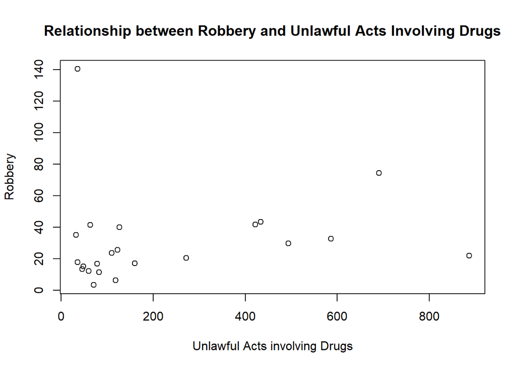

```r
plot(Euro_Crime_2019$Unlawful.acts.involving.controlled.drugs.or.precursors,
    Euro_Crime_2019$Robbery, xlab = "Unlawful Acts involving Drugs",
    ylab = "Robbery", main = "Relationship between Robbery and Unlawful Acts Involving Drugs")
```

# Task 3: Creativity

### Overall Offence Record

Plotting the Top 10 countries with the highest Overall offence record.

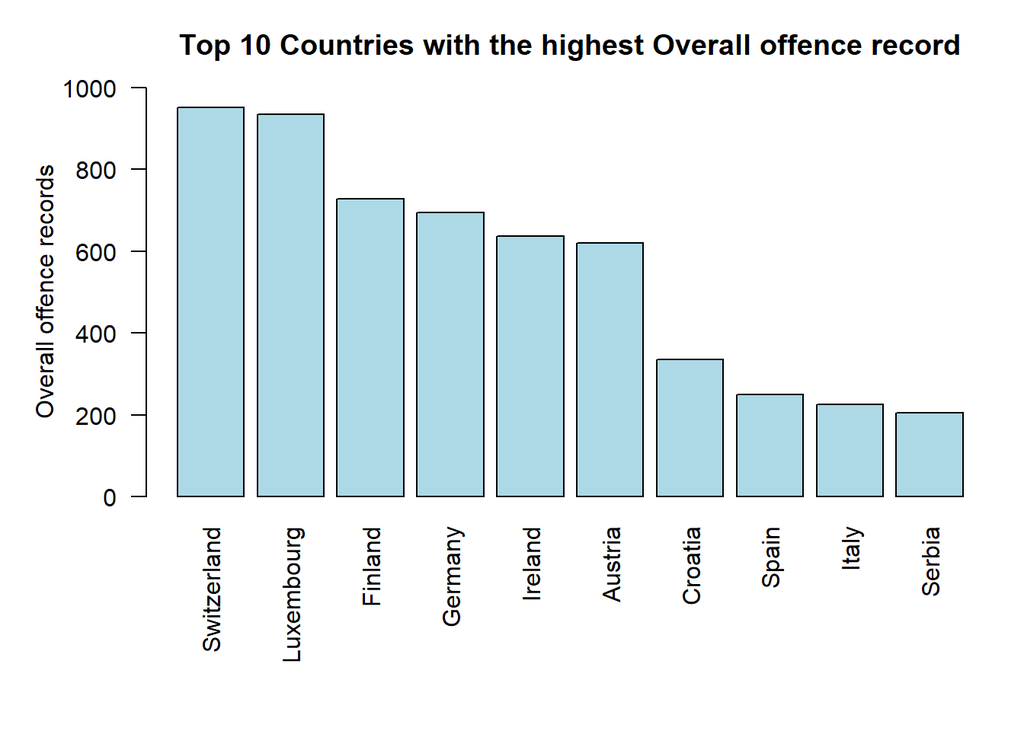

```r
overall <- Euro_Crime_2019[order(-Euro_Crime_2019$Overall), ]
row.names(overall)[4] = "Germany"
par(mar = c(8, 5, 3, 1))
barplot(overall[1:10, ]$Overall, names.arg = row.names(overall[1:10,
    ]), main = "Top 10 Countries with the highest Overall offence record",
    ylab = "Overall offence records", ylim = c(0, 1000), col = "lightblue",
    las = 2)
```

### Proportion of Drug Related Offences

Plotting the Top 10 countries with the highest proportion of ‘Unlawful.acts.involving.controlled.drugs.or.precursors’

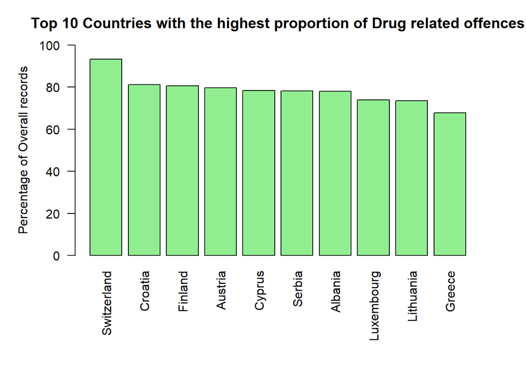

```r
Unlawful_Perc <- round((100 * Euro_Crime_2019[, "Unlawful.acts.involving.controlled.drugs.or.precursors"])/Euro_Crime_2019[,
    "Overall"], 2)
Euro_Crime_2019_New <- cbind(Euro_Crime_2019, Unlawful_Perc)

Euro_Crime_2019_New <- Euro_Crime_2019_New[order(-Euro_Crime_2019_New$Unlawful_Perc),
    ]
par(mar = c(8, 5, 3, 3))
barplot(Euro_Crime_2019_New[1:10, ]$Unlawful_Perc, names.arg = row.names(Euro_Crime_2019_New[1:10,
    ]), main = "Top 10 Countries with the highest proportion of Drug related offences",
    ylab = "Percentage of Overall records", ylim = c(0, 100),
    col = "lightgreen", las = 2)
```